# 클래스, 인스턴스, 메서드, super, 오버라이딩의 이해

### [객체지향언어란?]

- 객체 지향 프로그래밍은 컴퓨터 프로그래밍의 패러다임 중 하나이다. 객체 지향 프로그래밍은 컴퓨터 프로그램을 명령어의 목록으로 보는 시각에서 벗어나 여러 개의 독립된 단위, 즉 "객체"들의 모임으로 파악하고자 하는 것이다. 각각의 객체는 메시지를 주고받고, 데이터를 처리할 수 있다. (위키백과)
- 프로그램종류에 따라 객체지향 지원여부가 다름(파이썬은 객체지향 가능함)
- 객체지향언어의 장점
  - 객체지향언어의 재사용성
  - 생산성 증가(립된 객체로 이루어져있기 때문에 생산적으로 작업할 수 있고, 유지 및 보수가 용이함)
  - 자연스러운 모델링
- 객체지향언어의 단점
  - 느린 개발 속도(모든 객체의 역할과 기능을 이해해야 하기 때문에 프로그래밍에 많은 시간이 소요됨)
  - 느린 실행 속도
  - 객체지향언어는 대체로 난이도가 높음 (상속성, 캡슐화, 추상화등 이론적 배경도 필요함)
- 간단비교

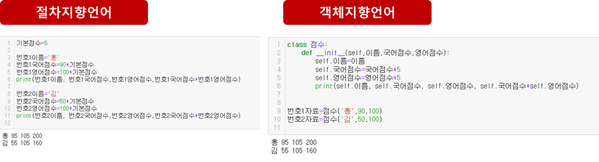

- 지금 하단의 자료 보지 말고 모든 작업이 끝난뒤다시 이론을 재정비합니다.
  - 구글검색 (filetype:pdf 객체지향)
  - 참고사이트: https://taste-and-investment.tistory.com/entry/%EA%B0%9D%EC%B2%B4%EC%A7%80%ED%96%A5-%EC%96%B8%EC%96%B4%EC%9D%98-%EC%9E%A5%EC%A0%90%EA%B3%BC-%EB%8B%A8%EC%A0%90-%EA%B0%9C%EB%85%90-%EC%A2%85%EB%A5%98-%EC%A0%88%EC%B0%A8%EC%A7%80%ED%96%A5-%EC%96%B8%EC%96%B4%EC%99%80-%EB%B9%84%EA%B5%90

### [1] **class란?**

- 실세계의 것을 모델링하여 속성(attribute)와 동작(method)를 갖는 데이터 타입
- python에서의 string, int, list, dict.. 모두가 다 클래스로 존재
- 예를들어 학생이라는 클래스를 만든다면, 학생을 나타내는 속성과 학생이 행하는 행동을 함께 정의 할 수 있음
- 따라서, 다루고자 하는 데이터(변수) 와 데이터를 다루는 연산(함수)를 하나로 캡슐화(encapsulation)하여 클래스로 표현
- 모델링에서 중요시 하는 속성에 따라 클래스의 속성과 행동이 각각 달라짐

### [2] **object(객체) 란?**

- 클래스로 생성되어 구체화된 실체(instance) 값임. object(객체)=instance(인스턴스)
- 파이썬의 모든 것(int, str, list..etc)은 객체(인스턴스)
- 실제로 class가 인스턴스화 되어 메모리에 상주하는 상태를 의미
- class가 빵틀이라면, object(객체)는 실제로 빵틀로 찍어낸 빵이라고 비유 가능
  - 프로그램 코드 상에서 자료형이 임의의 클래스로 선언된 식별자는 '객체'라 하고, 코드 컴파일 후 프로그램이 실행될 때 해당 객체가 메모리에 적재되면 '인스턴스'라고 불림

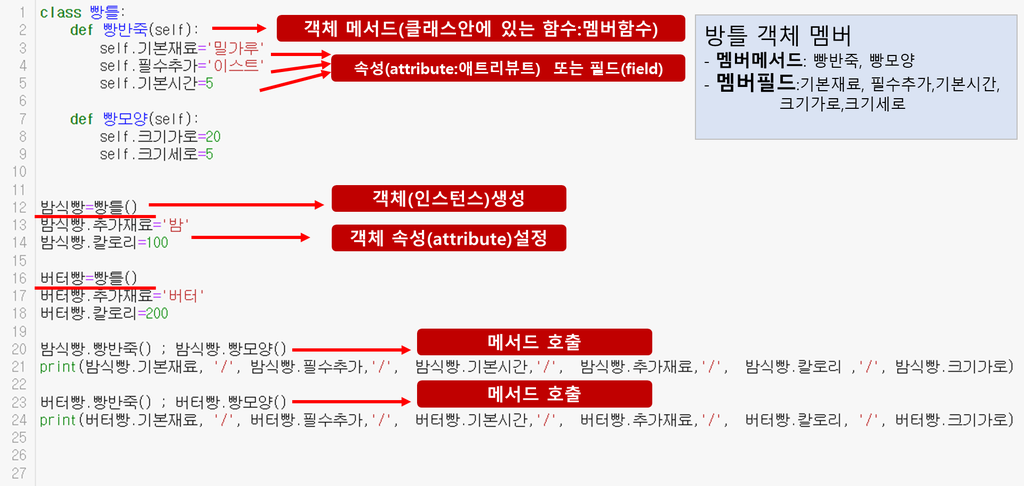

```python
class 빵틀:
    def 빵반죽(self):  # 메서드(멤버함수)
        self.기본재료='밀가루'   # 애트리뷰트 정의
        self.필수추가='이스트'   # 애트리뷰트 정의
        self.기본시간=5          # 애트리뷰트 정의

    def 빵모양(self): # 메서드(멤버함수)
        self.크기가로=20        # 애트리뷰트 정의
        self.크기세로=5         # 애트리뷰트 정의


밤식빵=빵틀()   # 객체(인스턴스) 생성
밤식빵.추가재료='밤'  # 클래스에 없는 객체 애트리뷰트 생성 및 값 설정
밤식빵.칼로리=100     # 클래스에 없는 객체 애트리뷰트 생성 및 값 설정

버터빵=빵틀()  # 객체(인스턴스) 생성
버터빵.추가재료='버터'  # 클래스에 없는 객체 애트리뷰트 생성 및 값 설정
버터빵.칼로리=200       # 클래스에 없는 객체 애트리뷰트 생성 및 값 설정

밤식빵.빵반죽() ; 밤식빵.빵모양() # 메서드(멤버함수)호출
print(밤식빵.기본재료, '/', 밤식빵.필수추가,'/',  밤식빵.기본시간,'/',  밤식빵.추가재료,'/',  밤식빵.칼로리 ,'/', 밤식빵.크기가로)

밤식빵.기본재료='밤+밀가루'  # 메서드내의 애트리뷰트값 변경
print(밤식빵.기본재료)

print('-' * 100)
버터빵.빵반죽() ; 버터빵.빵모양() # 메서드(멤버함수)호출
print(버터빵.기본재료, '/', 버터빵.필수추가,'/',  버터빵.기본시간,'/',  버터빵.추가재료,'/',  버터빵.칼로리, '/', 버터빵.크기가로)
```

[output not shown]

```python
### 에러 살펴보기
class 빵틀:

    def 빵반죽(self):  # 메서드(멤버함수)
        self.기본재료='밀가루'   # 애트리뷰트
        self.필수추가='이스트'   # 애트리뷰트
        self.기본시간=5          # 애트리뷰트

밤식빵=빵틀()  # 객체(인스턴스) 생성

#밤식빵.기본재료='밀가루'   ##----> 이 구문을 주석달면 에러

print(밤식빵.기본재료)     # 10번을 주석달고 실행시 ' 빵틀' object has no attribute '기본재료'
                           # 기본재료는 빵반죽함수에 있기때문에, 빵반죽 함수(메서드)를 호출해야함.
```

```
---------------------------------------------------------------------------
AttributeError                            Traceback (most recent call last)
~\AppData\Local\Temp/ipykernel_23044/2849778856.py in <module>
     11 #밤식빵.기본재료='밀가루'   ##----> 이 구문을 주석달면 에러
     12
---> 13 print(밤식빵.기본재료)     # 10번을 주석달고 실행시 ' 빵틀' object has no attribute '기본재료'
     14                            # 기본재료는 빵반죽함수에 있기때문에, 빵반죽 함수(메서드)를 호출해야함.
     15

AttributeError: '빵틀' object has no attribute '기본재료'
```

```python
### 에러 해결하기, 기본재료 attribute(애트리뷰트)가 있는 빵반죽함수(메서드)를 호출해야함.
class 빵틀:

    def 빵반죽(self):   # 메서드(멤버함수)
        self.기본재료='밀가루'    # 애트리뷰트
        self.필수추가='이스트'    # 애트리뷰트
        self.기본시간=5           # 애트리뷰트

밤식빵=빵틀()   # 객체(인스턴스)생성
#밤식빵.기본재료='밀가루'   ##----> 이 구문을 주석달면 에러

밤식빵.빵반죽()       #메서드를 호출해야함.
print(밤식빵.기본재료)     # 10번을 주석달고 실행시 ' 빵틀' object has no attribute '기본재료'
                           # 기본재료는 빵반죽함수에 있기때문에, 빵반죽 함수(메서드)를 호출해야함.
```

```
밀가루
```

```python
### (참고) 모든메뉴의 기본자료라면 빵틀 클래스가 실행되는순간 초기값에 넣어서(생성자) 별도의 메서드 호출없이 사용할수 있음.
### 하단의 [3] class 선언및 생성자에서 확인함.
class 빵틀:
    def __init__(self):    # 생성자 (빵틀 클래스 실행시 자동 실행되는 메서드(함수))
        self.기본재료='밀가루'  # 생성자내의 애트리뷰트

밤식빵=빵틀() # 객체(인스턴스)생성시 def __init__ (생성자) 메서드내의 애트리뷰트(기본재료)를 사용할수 있음.
밤식빵.기본재료
```

```
'밀가루'
```

### [3] **class 선언 및 생성자**

- 객체를 생성하기 위해선 객체의 모체가 되는 class를 미리 선언해야 함
- 클래스선언된 type은 출력해 보면 **main**.클래스명으로 type이 출력됨

### __init__(self) : 생성자로서 클래스 인스턴스가 생성될때 호출됨

클래스 내에서 특별한 이름(**init**)을 갖기만 하면 객체가 생성될 때 자동으로 호출되는 함수를 생성자라함. 객체가 생성될 때 자동으로 호출되기 때문에 객체를 초기화하거나 초깃값을 설정하는데 유용하게 사용됨

- self인자는 항상 첫번째에 오며 자기 자신을 가리킴
- 이름이 꼭 self일 필요는 없지만, 관례적으로 self로 사용
  - (참고) C++/C#, Java의 this에 해당
- 생성자에서는 해당 클래스가 다루는 데이터를 정의
  - 이 데이터를 멤버 변수(member variable) 또는 속성(attribute)라고 함

```python
# 클래스 타입 확인용
class Person:
    pass

김강희 = Person()  #객체(인스턴스) 생성
박성훈 = Person()  #객체(인스턴스) 생성

a = list()
b = list()

print(type(김강희), type(박성훈))
print(type(a), type(b))
```

```
<class '__main__.Person'> <class '__main__.Person'>
<class 'list'> <class 'list'>
```

```python
########### 생성자 ########

class Person:
    def __init__(self):
        print("태어남..")

p = Person()  #  객체(인스턴스생성시) 클래스의 __init__ 생성자 메서드가 자동호출되면서 print구문이 실행됨
```

```
태어남..
```

```python
## 생성자 사용예 1

class Person:
    def __init__(self):     # 생성자
        print(self, 'is generated')   # 이코드의 행번호 11, 16번의 p1,p2 객체(인스턴스) 생성명령이 실행될때 print구문이 동작하게됨
        print('Person 클래스를 실행합니다')
        self.name = 'Kate'   # 생성자(클래스메서드(멤버함수)) 애트리뷰트(속성)값  (객체멤버라고하기도함)
        self.age = 10        # 생성자(클래스메서드(멤버함수)) 애트리뷰트(속성)값  (객체멤버라고하기도함)


p1 = Person()  # 객체(인스턴스) 생성
print(p1.name, '/', p1.age)  # __init__ 생성자메서드의 애트리뷰트값을 출력


print('\n\n' + '-'*100)
p2 = Person()  # 객체(인스턴스) 생성

p2.name = 'aaron' #생성된 객체(인스턴스) p2의 name 애트리뷰트값을 설정함 (생성자에 있는 name값을 변경함.)
p2.age = 20       #생성된 객체(인스턴스) p2의 age 애트리뷰트값을 설정함 (생성자에 있는 age값을 변경함.)

print(p2.name, '/', p2.age)
```

```
<__main__.Person object at 0x000002B5615186A0> is generated
Person 클래스를 실행합니다
Kate / 10


----------------------------------------------------------------------------------------------------
<__main__.Person object at 0x000002B56151F430> is generated
Person 클래스를 실행합니다
aaron / 20
```

```python
## 생성자 사용예 2

class Person:
    # 생성자에 매개변수를 선언한경우임  (self, name, age 를 매개변수라함)
    #이코드 8,9,10번행의 p1,p2,p3 객체(인스턴스) 생성시 name은 값이 있어야하고, age는 없으면 기본으로 10을 할당함
    def __init__(self, name, age=10):
        self.name = name   # 이코드 8,9,10번행의 p1,p2,p3 객체(인스턴스) 생성할때 넣어준 name값 받아옴
        self.age = age     # 이코드 8,9,10번행의 p1,p2,p3 객체(인스턴스) 생성할때 넣어준 age값 받아옴

p1 = Person('Bob', 30)  # 객체(인스턴스)생성시 생성자의 name 애트리뷰트(속성)에 'Bob', age 애트리뷰트에 30 값 argument(인자)전달
p2 = Person('Kate', 20) # 객체(인스턴스)생성시 생성자의 name 애트리뷰트(속성)에 'Kate', age 애트리뷰트에 20 값 argument(인자)전달
p3 = Person('Aaron')    # 객체(인스턴스)생성시 생성자의 name 애트리뷰트(속성)에 'Aaron' 값 argument(인자)전달
                        # age 매개변수값에 필요한 argument(인자)값을 넣지 않아서 __init__( age=10)값이 자동 할당됨

print(p1.name, p1.age)
print(p2.name, p2.age)
print(p3.name, p3.age)
```

```
Bob 30
Kate 20
Aaron 10
```

```python
## 참고: *argument 를 활용해봅니다. (클래스내의 모든 멤버함수(메서드)에 사용가능함)
## *argument는 매개변수의 갯수가 정해져 있지 않을때 사용하는 방법입니다.
## 통상적으로 *arg라고 표현하나 *뒤의 이름은 사용자 정의어입니다.

class Person:
    def __init__(self,*data):
        self.name = data[0]
        self.age = data[1]

p1=Person('bu',30)  # pa=Person('bu',30,20,10) argument 갯수값이 많아도 __init__ 에서 data[0]과 data[1]만 사용함
p1.name, p1.age
```

```
('bu', 30)
```

```python
## 참고: **kwargs(keyword argument) 를 활용해봅니다. (클래스내의 모든 멤버함수(메서드)에 사용가능함)
## kwargs는 매개변수를 딕셔너리 형태로 처리할수 있습니다.

class Person:
    def __init__(self,**data):
        self.name = data['name']
        self.age = data['age']

p1=Person(name=['bu','song'],age=[30,50])
print(p1.name, p1.age)
print(p1.name[0], p1.age[0])
print(p1.name[1], p1.age[1])
```

```
['bu', 'song'] [30, 50]
bu 30
song 50
```

-- 참고 --

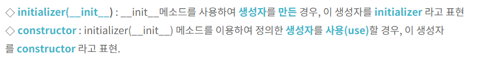

```python
class Person:
    def __init__(self, name, age):
        self.name = name
        self.age = age

    def sleep(self):
        print(self.name, '은 잠을 잡니다.')

a = Person('Aaron', 20)
b = Person('Bob', 30)


a.sleep()
b.sleep()
```

```
Aaron 은 잠을 잡니다.
Bob 은 잠을 잡니다.
```

### [4] **mehtod 자세히**

- 멤버함수라고도 하며, 해당 클래스의 object에서만 호출가능
- 메서드는 객체 레벨에서 호출되며, 해당 객체의 속성에 대한 연산을 행함
- {obj}.{method}() 형태로 호출됨

#### [4-1] 메서드 샘플

```python
# 1. 숫자를 하나 증가
# 2. 숫자를 0으로 초기화
class Counter:
    def __init__(self):  #생성자 Counter함수가 호출되면
        self.num = 0     # 생성자내의 멤버애트리뷰트(필드,속성)값이 0으로 세팅됨

    def increment(self): # 생성자값에서 생성한 num  애튜리뷰트값을 받아올수 있음.
        self.num += 1

    def reset(self):
        self.num = 0

    def print_current_value(self):
        print('현재값은:', self.num)


c1 = Counter()
c1.print_current_value()
c1.increment()
c1.increment()
c1.increment()
c1.print_current_value()

c1.reset()

c1.print_current_value()

c2 = Counter()
c2.increment()
c2.print_current_value()
```

```
현재값은: 0
현재값은: 3
현재값은: 0
현재값은: 1
```

#### [4-2] 메서드 type

- instance method - 객체로 호출
  - 메서드는 객체 레벨로 호출 되기 때문에, 해당 메서드를 호출한 객체에만 영향을 미침
    - 지금까지 한 자료가 인스턴스메서드임. p1=Person() 처럼 p1 인스턴스를 생성해서 작업함.
    - self 가 있는 클래스
- class method(static method) - class로 호출
  - 클래스 메서드의 경우, 클래스 레벨로 호출되기 때문에, 클래스 멤버 변수만 변경 가능
    - 여러개의 함수를 모아놓은 함수집합체로서만의 역할을 필요로 할때 사용
    - self 없는 클래스

```python
 # - instance method - 객체로 호출
class 성적:
    def __init__(self,name,kor,eng):
        self.name=name
        self.kor=kor+5    #생성자에서 5점 추가한값을 기본으로 제공
        self.eng=eng+5    #생성자에서 5점 추가한값을 기본으로 제공
        print('인스턴스생성할때 사용자가 입력한값입니다, __init__에서 출력함==>',name,kor,eng)

    def add(self):
        return self.kor+self.eng

    def mul(self):
        return self.kor*self.eng

값1=성적('aaa',10,20)
값2=성적('bbb', 100,200)

print('\n {}의 성적은 국어 {}, 영어{} 점이며 총점은 {}점입니다.'.format(값1.name, 값1.kor, 값1.eng, 값1.add()))
print('\n {}의 성적은 국어 {}, 영어{} 점이며 총점은 {}점입니다.'.format(값2.name, 값2.kor, 값2.eng, 값2.add()))
```

```
인스턴스생성할때 사용자가 입력한값입니다, __init__에서 출력함==> aaa 10 20
인스턴스생성할때 사용자가 입력한값입니다, __init__에서 출력함==> bbb 100 200

 aaa의 성적은 국어 15, 영어25 점이며 총점은 40점입니다.

 bbb의 성적은 국어 105, 영어205 점이며 총점은 310점입니다.
```

```python
# - class method(static method) - class로 호출

class 성적:

    def add(kor,eng):
        kor=kor+5
        eng=eng+5
        return kor+eng

    def mul( kor,eng):
        kor=kor+5
        eng=eng+5
        return kor* eng
값1_name='aaa'; 값1_kor=10; 값1_eng=20
값1=성적.add(값1_kor,값1_eng)

값2_name='bbb'; 값2_kor=100; 값2_eng=200
값2=성적.add(값2_kor,값2_eng)


print('\n {}의 성적은 국어 {}, 영어{} 점이며 총점은 {}점입니다.'.format(값1_name, 값1_kor, 값1_eng, 값1))
print('\n {}의 성적은 국어 {}, 영어{} 점이며 총점은 {}점입니다.'.format(값2_name, 값2_kor, 값2_eng, 값2))
```

```
 aaa의 성적은 국어 10, 영어20 점이며 총점은 40점입니다.

 bbb의 성적은 국어 100, 영어200 점이며 총점은 310점입니다.
```

```python
# 클래스 예제.
# Point
# 2차원 좌표평면 각 점(x, y)
# 연산
# 두점 의 덧셈, 뺄셈 (1, 2) + (3, 4) = (4, 6)
# 한점과 숫자의 곱셈 (1,  2) * 3 = (3, 6)
# 그 점의 길이 (0,0) 부터의 거리
# x, y 값 가져오기
# 출력하기

class Point:
    def __init__(self, x, y):
        self.x = x
        self.y = y

    def __add__(self, pt):
        new_x = self.x + pt.x
        new_y = self.y + pt.y
        return Point(new_x, new_y)

    def __sub__(self, pt):
        new_x = self.x - pt.x
        new_y = self.y - pt.y
        return Point(new_x, new_y)

    def __mul__(self, factor):
        return Point(self.x * factor, self.y * factor)

    def __getitem__(self, index):
        if index == 0:
            return self.x
        elif index == 1:
            return self.y
        else:
            return -1

    def __len__(self):
        return self.x ** 2 + self.y ** 2

    def __str__(self):
        return '({}, {})'.format(self.x, self.y)

p1 = Point(3, 4)
p2 = Point(2, 7)

a = 1 + 2
p3 = p1 + p2
p4 = p1 - p2

# p5 = p1.multiply(3)
p5 = p1 * 3

print(len(p1))

# p1[0] -> x
# p1[1] -> y
print(p1[0])
print(p1[1])
print(p1)
print(p2)
print(p3)
print(p4)
print(p5)
```

[output not shown]

```python
### 데코레이터는 클래스 학습 다 끝나고 다시 학습하세요.. 이 노트부분은 그냥 쓱 읽으셔요.
### 데코레이터의 이해  (다음노트에서 @staticmethod 데코레이션을 사용함으로 데코레이션 이해가 필요함)
## 데코레이터는 함수를 수정하지 않은 상태에서 추가 기능을 구현할 때 사용합니다.
## 예를 들어서 함수의 시작과 끝을 출력하고 싶다면 다음과 같이 함수 시작, 끝 부분에 print를 넣어주어야 합니다.

### https://dojang.io/mod/page/view.php?id=2427/   ===> 클래스 학습 끝나고 봐도 됨

def hello():
    print('hello 함수 시작')
    print('hello')
    print('hello 함수 끝')

def world():
    print('world 함수 시작')
    print('world')
    print('world 함수 끝')
print(hello())
print(world())

print('-' *100)


# --------------------------------------------------------------------------------------------------------------
# 만약 다른 함수도 시작과 끝을 출력하고 싶다면 함수를 만들 때마다 print를 넣어야 합니다.
# 따라서 함수가 많아지면 매우 번거로워집니다.
# 이런 경우에는 데코레이터를 활용하면 편리합니다. 다음은 함수의 시작과 끝을 출력하는 데코레이터입니다.

def trace(func):                             # 호출할 함수를 매개변수로 받음
    def wrapper():                           # 호출할 함수를 감싸는 함수
        print(func.__name__, '함수 시작')    # __name__으로 함수 이름 출력
        func()                               # 매개변수로 받은 함수를 호출
        print(func.__name__, '함수 끝')
    return wrapper                           # wrapper 함수 반환

def hello():
    print('hello')

def world():
    print('world')

trace_hello = trace(hello)    # 데코레이터에 호출할 함수를 넣음
trace_hello()                 # 반환된 함수를 호출
trace_world = trace(world)    # 데코레이터에 호출할 함수를 넣음
trace_world()                 # 반환된 함수를 호출


# --------------------------------------------------------------------------------------------------------------
print('-'*100)
print('@를 이용한 데코레이터')
# @을 사용하여 좀 더 간편하게 데코레이터를 사용해보겠습니다. 다음과 같이 호출할 함수 위에 @데코레이터 형식으로 지정합니다.

def trace(func):                             # 호출할 함수를 매개변수로 받음
    def wrapper():
        print(func.__name__, '함수 시작')    # __name__으로 함수 이름 출력
        func()                               # 매개변수로 받은 함수를 호출
        print(func.__name__, '함수 끝')
    return wrapper                           # wrapper 함수 반환

@trace    # @데코레이터
def hello():
    print('hello')

@trace    # @데코레이터
def world():
    print('world')

hello()    # 함수를 그대로 호출
world()    # 함수를 그대로 호출
```

[output not shown]

```python
#######-- 그냥 개념정도만 함수형클래스임을 읨한다 정도만.  클래스 다 끝나고 다시 보세요.
# 참고 클래스메소드를 @staticmethod (정적) 데코레이터(바로 다음 노트창에 설명 있음)를 붙여서 작성하기도 함
# staticmethod 에 대해서는 아래 사이트 참조  (내용이 길수 있음으로 추후에 보아도 됨)
# https://myjamong.tistory.com/289    -------------------> 클래스 학습끝나고 보셔요
# 현재는 8,12번행의 staticmethod 메소드는 사용하지 않아도 결과는 동일함

class Math:
    @staticmethod
    def add(a, b):
        return a + b

    @staticmethod
    def multiply(a, b):
        return a * b

Math.add(10, 20)
Math.multiply(10, 20)
```

```
200
```

### [5] **Class Inheritance (상속)** ,코드재사용

- 기존에 정의해둔 클래스의 기능을 그대로 물려받을 수 있다.
- 기존 클래스에 기능 일부를 추가하거나, 변경하여 새로운 클래스를 정의한다.
- 코드를 재사용할 수 있게된다.
- 상속 받고자 하는 대상인 기존 클래스는 (Parent, Super, Base class 라고 부른다.)
- 상속 받는 새로운 클래스는(Child, Sub, Derived class 라고 부른다.)
- 의미적으로 is-a관계를 갖는다
- 물려주는 클래스를 부모클래스(Super class), 물려받는 클래스를 자식클래스(Sub class)

#### [5-1] 객체지향 class 예제

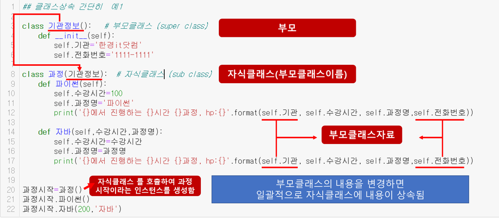

```python
############################
#####  예제 1
#############################

class 기관정보():   # 부모클래스 (super class)
    def __init__(self):
        self.기관='한경it닷컴'
        self.전화번호='1111-1111'

class 과정(기관정보):  # 자식클래스 (sub class)
    def 파이썬(self):
        self.수강시간=100
        self.과정명='파이썬'
        print('{}에서 진행하는 {}시간 {}과정, hp:{}'.format(self.기관, self.수강시간, self.과정명,self.전화번호))

    def 자바(self,수강시간,과정명):
        self.수강시간=수강시간
        self.과정명=과정명
        print('{}에서 진행하는 {}시간 {}과정, hp:{}'.format(self.기관, self.수강시간, self.과정명,self.전화번호))


과정시작=과정()
과정시작.파이썬()
과정시작.자바(200,'자바')
```

```
한경it닷컴에서 진행하는 100시간 파이썬과정, hp:1111-1111
한경it닷컴에서 진행하는 200시간 자바과정, hp:1111-1111
```

```python
############################
#####  예제 2
#############################


class prn():    #함수형 클래스
    def line():
        print('-'*100)

    def sub(부모이름, 이름, 본적):
        prn.line()
        print('부모님이름:{} / 내이름:{} /  본적:{}'.format(자식.부모이름, 자식.이름, 자식.본적))


## 클래스상속 간단히  예2
### --- 객체지향 클래스 ----
class 부모클래스:
    def __init__(self):
        self.부모이름='홍길동'
        self.본적='서울'

class 자식클래스(부모클래스):
    def 자식1(self,이름):
        self.이름=self.부모이름[:1]+이름
        prn.sub(self.부모이름, self.이름,self.본적)

    def 자식2(self,이름):
        self.이름=self.부모이름[:1]+이름
        prn.sub(self.부모이름, self.이름,self.본적)

class 손자클래스(자식클래스):
    def 손자1(self):
        prn.line()
        print('부모님의 부모님이름은 {}입니다'.format(self.부모이름))


자식인스턴스=자식클래스()
자식인스턴스.자식1('가희')# sub(자식.부모이름, 자식.이름, 자식.본적)
자식인스턴스.자식2('승인')# sub(자식.부모이름, 자식.이름, 자식.본적)

손자인스턴스=손자클래스()
손자인스턴스.손자1()
```

[output not shown]

#### [5-2] 객체지향 super 사용

- super 명령어는 상속 관계에서 상속의 대상인 부모 클래스를 호출하는 함수

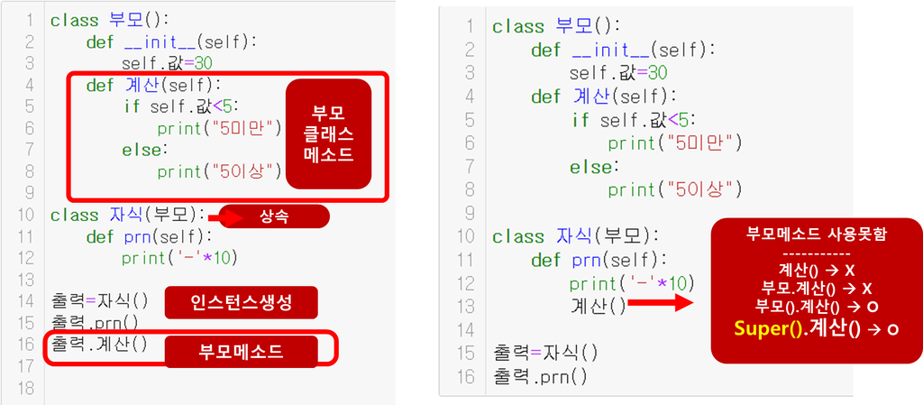

```python
#########################################
### super의  다른 사용 예
### 부모클래스에도 init, prn
### 자식클래스에도 init, prn 이 둘다 있을때
### 이렇게 부모와 자식에 같은 def 이름이 있는 중복 def를 오버라이딩이라 함
### 오버라이딩은 [6]번에서 다시봄- 여기서는 init나 prn처럼 같은 함수가 있어도 부모함수를 호출하지 않으면
### 자식함수(메서드)가 실행되어서 부모의 함수(메서드)를 다룰때는 super 또는 부모함수().메서드() 로 실행됨을 알고 있으면 됨
##########################################
class 부모():
    def __init__(self):
        self.값=30
        print('부모클래스 프린트임')

    def prn(self):
        print('★'*10)

class 자식(부모):
    def __init__(self):
        print('자식클래스 프린트임')

    def prn(self):
        print('-'*10)
출력=자식()
출력.prn()                         # 자식클래스에 있는 __init__가 먼저 실행됨
super(자식, 출력).__init__()       #자식클래스의 부모값을 실행함
super(자식, 출력).prn()            # 자식클래스의 부모값을 실행함
```

```
자식클래스 프린트임
----------
부모클래스 프린트임
★★★★★★★★★★
```

```python
########################################
### super의  다른 사용 예 (생성자에서 생성자 내용호출)
### 부모클래스에도 init, prn
### 자식클래스에도 init, prn 이 둘다 있을때
##########################################
class 부모():
    def __init__(self):
        self.값=30
        print('부모클래스 프린트문임')

    def prn(self):
        print('★'*10)

class 자식(부모):
    def __init__(self):
        super().__init__()               # ---------> 자식클래스 생성자에서 부모클래스의 생성자 호출
        super().prn()                    # ---------> 자식클래스 생성자에서 부모클래스의 prn() 메소드 호출
        print('자식클래스 프린트문임')

    def prn(self):
        print('-'*10)
출력=자식()
출력.prn()   # 자식클래스에 있는 __init__가 먼저 실행됨
```

```
부모클래스 프린트문임
★★★★★★★★★★
자식클래스 프린트문임
----------
```

```python
########################################
### super의  다른 사용 예
### 자식클래스의 생성자에서 부모클래스의 생성자값 호출시
### 매개변수 있을때
##########################################
class 부모():
    def __init__(self,값,횟수,모양):
        self.값=값
        self.횟수=횟수
        self.모양=모양
        print('부모클래스 프린트문임')
        print('자식클래스에서 입력한값은 {}임'.format(self.값))

        if self.값>=30:
            print('30이상')
        else:
            print('30미만')

    def prn(self,횟수,모양):
        self.횟수=횟수
        self.모양=모양
        print(self.모양*self.횟수)

class 자식1(부모):
    def __init__(self,값,횟수,모양):
        super().prn(횟수,모양)
        super().__init__(값,횟수,모양)               # ---------> 자식클래스 생성자에서 부모클래스의 생성자 호출
        super().prn(횟수,모양)

class 자식2(부모):
    def __init__(self,값,횟수,모양):
        self.횟수=횟수*50
        super().prn(self.횟수,모양)
        super().__init__(값,self.횟수,모양)               # ---------> 자식클래스 생성자에서 부모클래스의 생성자 호출
        super().prn(self.횟수,모양)

출력1=자식1(5,20,'★')   # 값은5, 출력횟수는 20번임
출력2=자식2(35,1,'●')   # 값은8, 출력횟수는 1번이지만 자식2의 인스턴스에 사용된 자식2클래스에는 self.횟수=self.횟수*50 식이 있음


# https://leemoney93.tistory.com/37   (에서 한번더 정리하세요)
```

```
★★★★★★★★★★★★★★★★★★★★
부모클래스 프린트문임
자식클래스에서 입력한값은 5임
30미만
★★★★★★★★★★★★★★★★★★★★
●●●●●●●●●●●●●●●●●●●●●●●●●●●●●●●●●●●●●●●●●●●●●●●●●●
부모클래스 프린트문임
자식클래스에서 입력한값은 35임
30이상
●●●●●●●●●●●●●●●●●●●●●●●●●●●●●●●●●●●●●●●●●●●●●●●●●●
```

### [6] **method override** (메서드 오버라이드, 오버라이딩)

- 부모 클래스의 method를 재정의(override)
- 하위 클래스(자식 클래스) 의 인스턴스로 호출시, 재정의된 메서드가 호출됨
- 아래코드 출처 및 설명
  - 메서드 오버라이딩(Method Overriding)이란, 여러 클래스에 걸쳐서 같은 이름의 메서드를 만드는 것이다. 예를 들어 부모 클래스, 전사 캐릭터 클래스, 마법사 캐릭터 클래스에 공통으로 attack이라는 메서드가 있지만, 각각 하는 일이 다를 때는 다음처럼 같은 이름의 메서드를 클래스별로 구현하면 된다. 이렇게 되면 부모 클래스에서 만든 메서드 정의를 자식 클래스에서는 변경해서 사용한다.

```
 - https://datascienceschool.net/01%20python/02.12%20%ED%8C%8C%EC%9D%B4%EC%8D%AC%20%EA%B0%9D%EC%B2%B4%EC%A7%80%ED%96%A5%20%ED%94%84%EB%A1%9C%EA%B7%B8%EB%9E%98%EB%B0%8D.html
```

```python
class Character(object):
    def __init__(self):
        self.life = 1000
        self.strength = 10
        self.intelligence = 10

    def attacked(self):
        self.life -= 10
        print("공격받음! 생명력 =", self.life)

    def attack(self):                              ####  ---> 부모클래스의 attack
        print("공격!")

class Warrior(Character):
    def __init__(self):
        super(Warrior, self).__init__()
        self.strength = 15
        self.intelligence = 5

    def attack(self):                               ####  ---> 자식클래스의 attack
        print("육탄 공격!")


class Wizard(Character):
    def __init__(self):
        super(Wizard, self).__init__()
        self.strength = 5
        self.intelligence = 15

    def attack(self):                          ####  ---> 자식클래스의 attack
        print("마법 공격!")

a = Character()    #부모클래스 인스턴스 생성
a.attack()     #==> 부모클래스의 attack 메서드 실행

b = Warrior()      #자식클래스 인스턴스 생성
b.attack()    ##--> 자식클래스의 attack 메서드 실행  (21번 행 실행됨)

c=Wizard(); c.attack() # --31번 행 실행됨
super(Wizard,c).attack()  # 부모 attack 실행
```

```
공격!
육탄 공격!
마법 공격!
공격!
```

### [7] **오버로딩 Overloading

- https://datascienceschool.net/01%20python/02.12%20%ED%8C%8C%EC%9D%B4%EC%8D%AC%20%EA%B0%9D%EC%B2%B4%EC%A7%80%ED%96%A5%20%ED%94%84%EB%A1%9C%EA%B7%B8%EB%9E%98%EB%B0%8D.html
- 오버라이드와 이름으로 오버로딩(Overloading)이라는 것이 있는데 이는 전혀 다른 개념이다. 오버로딩은 같은 메서드가 인수의 자료형이나 개수를 다르게 받을 수 있는 것을 말한다. C++, Java 등에서는 지원하지만, 파이썬에서는 오버로딩을 지원하지 않으므로 프로그래머가 내부적으로 알아서 처리해야 한다

### [8]**special method** (특수메서드)

- **로 시작** 로 끝나는 특수 함수
- 해당 메서드들을 구현하면, 커스텀 객체에 여러가지 파이썬 내장 함수나 연산자를 적용 가능
- 아래 사이트에서 참조함. (https://datascienceschool.net/01%20python/02.12%20%ED%8C%8C%EC%9D%B4%EC%8D%AC%20%EA%B0%9D%EC%B2%B4%EC%A7%80%ED%96%A5%20%ED%94%84%EB%A1%9C%EA%B7%B8%EB%9E%98%EB%B0%8D.html)

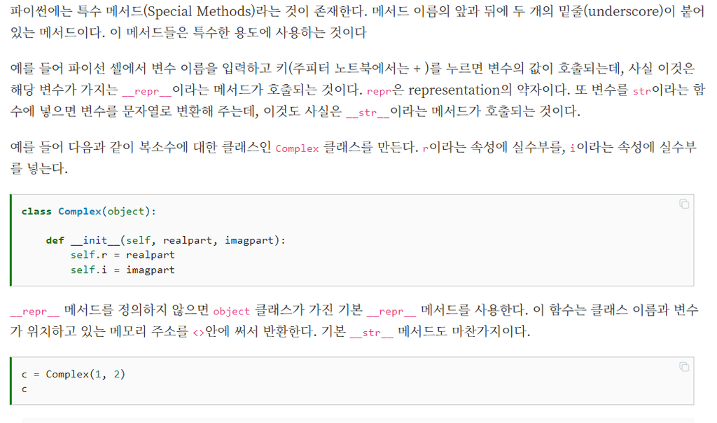

- 오버라이딩 가능한 함수 목록은 아래 링크에서 참조
  - https://docs.python.org/3/reference/datamodel.html
  - https://docs.python.org/3/reference/datamodel.html#object.__add__